# Impact of Weather Events to Population Health and Economics in the US

Nazmi Anik

Monday, September 21, 2015

## Synopsis

Our goal is to analyze the impact of weather events on public health and economy based on the data from the U.S. National Oceanic and Atmospheric Administration’s (NOAA) that was collected from 1950 - 2011. Impact of weather events to population health can be measured from the fatalities and injuries counts. Economic effects can be measured from property damage and crop damage values. Comparing the data for various weather event types, we found that tornadoes and excessive heat are most harmful with respect to population health; floods and hurricanes have the greatest economic impacts.

## Reading the Data

The data was obtained from the [Coursera Assignment Page](https://class.coursera.org/repdata-032/human_grading/view/courses/975145/assessments/4/submissions). The [data](https://d396qusza40orc.cloudfront.net/repdata%2Fdata%2FStormData.csv.bz2) for this assignment came in the form of a comma-separated-value file compressed via the bzip2 algorithm to reduce its size.

First the raw data is downloaded from the [link](https://d396qusza40orc.cloudfront.net/repdata%2Fdata%2FStormData.csv.bz2) that was provided.

```r
#if file is not already downloaded, download it
if(!file.exists("stormdata.csv.bz2")){
    url <- "https://d396qusza40orc.cloudfront.net/repdata%2Fdata%2FStormData.csv.bz2"
    download.file(url, destfile = "stormdata.csv.bz2", mode = "wb")
}
```

The data, then was read into a data frame using the *read.csv* function.

```r
#read the data into a data frame
storm <- read.csv("stormdata.csv.bz2", stringsAsFactors=FALSE, na.strings="NA")
head(storm)
```

```
##   STATE__           BGN_DATE BGN_TIME TIME_ZONE COUNTY COUNTYNAME STATE
## 1       1  4/18/1950 0:00:00     0130       CST     97     MOBILE    AL
## 2       1  4/18/1950 0:00:00     0145       CST      3    BALDWIN    AL
## 3       1  2/20/1951 0:00:00     1600       CST     57    FAYETTE    AL
## 4       1   6/8/1951 0:00:00     0900       CST     89    MADISON    AL
## 5       1 11/15/1951 0:00:00     1500       CST     43    CULLMAN    AL
## 6       1 11/15/1951 0:00:00     2000       CST     77 LAUDERDALE    AL
##    EVTYPE BGN_RANGE BGN_AZI BGN_LOCATI END_DATE END_TIME COUNTY_END
## 1 TORNADO         0                                               0
## 2 TORNADO         0                                               0
## 3 TORNADO         0                                               0
## 4 TORNADO         0                                               0
## 5 TORNADO         0                                               0
## 6 TORNADO         0                                               0
##   COUNTYENDN END_RANGE END_AZI END_LOCATI LENGTH WIDTH F MAG FATALITIES
```

[output cut: 20 more lines]

## Processing the Data

```r
#convert beginning date column into date class
storm[,2] <- as.Date(storm[,2],format='%m/%d/%Y %H:%M:%S')
```

### Removing Unused Columns

Data is subset with the relevant columns. Since we are looking at data across the United States, location data is irrelevant. *Injuries* and *Fatalities* columns provide data about population health. *Property Damage* and *Crop Damage* columns provide economic data. The *Event Type* column gives us which event caused the problems.

```r
#subset all of the data with the selected columns
stormSub <- subset(storm, select=c(EVTYPE, BGN_DATE, FATALITIES, INJURIES, PROPDMG, PROPDMGEXP, CROPDMG, CROPDMGEXP), stringsAsFactors=FALSE)
str(stormSub)
```

```
## 'data.frame':    902297 obs. of  8 variables:
##  $ EVTYPE    : chr  "TORNADO" "TORNADO" "TORNADO" "TORNADO" ...
##  $ BGN_DATE  : Date, format: "1950-04-18" "1950-04-18" ...
##  $ FATALITIES: num  0 0 0 0 0 0 0 0 1 0 ...
##  $ INJURIES  : num  15 0 2 2 2 6 1 0 14 0 ...
##  $ PROPDMG   : num  25 2.5 25 2.5 2.5 2.5 2.5 2.5 25 25 ...
##  $ PROPDMGEXP: chr  "K" "K" "K" "K" ...
##  $ CROPDMG   : num  0 0 0 0 0 0 0 0 0 0 ...
##  $ CROPDMGEXP: chr  "" "" "" "" ...
```

Let’s also look at years that we want to include in the processing. Earlier years usually do not have accurate or well-kept data. It may prove worthwile to not include some earlier years in our analysis.

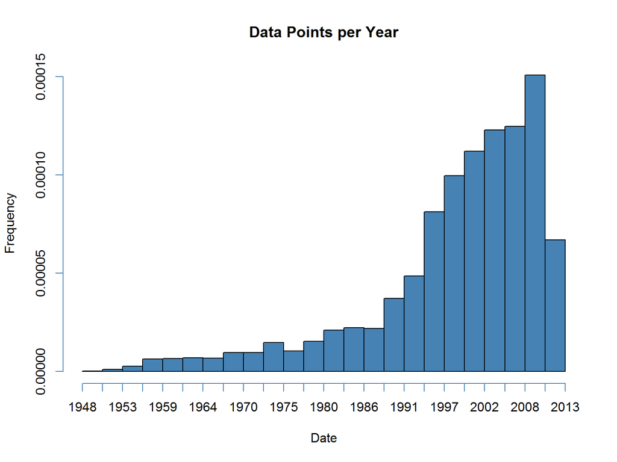

```r
#draw a histogram to see how much data was gathered each year
hist(stormSub$BGN_DATE, main="Data Points per Year", xlab="Date", ylab="Frequency", col = "steelblue", breaks = 25)
```

```r
#subset all of the data with the dates after 1989
stormSub <- subset(stormSub, BGN_DATE > "1988-12-31", stringsAsFactors=FALSE)
```

### Creating New Useful Columns

Looking at *Property Damage Exponential* and *Crop Damage Exponential* columns to figure out a way to compute the corresponding damage amount.

```r
paste(unique(stormSub$PROPDMGEXP))
```

```
##  [1] "M" "K" ""  "B" "m" "+" "0" "5" "6" "?" "4" "2" "3" "h" "7" "H" "-"
## [18] "1" "8"
```

```r
paste(unique(stormSub$CROPDMGEXP))
```

```
## [1] ""  "M" "K" "m" "B" "?" "0" "k" "2"
```

In the EXP data columns, the “M” corresponds to a million, “B” to a billion, “K” to a thousand, “H” to a hundred, and the numbers correspond to the exponential value of 10 (as in “10 to the power of x”). We need to make these conversions so we can compare the data better. The remainder of the values “?,+,-” will be assumed as 0 to be able to ignore possibly wrong data recordings and simplify the analysis.

```r
#create a new column with numeral values for Property Damage Exponential column
stormSub$PROPEXP[stormSub$PROPDMGEXP == ""] <- 1
stormSub$PROPEXP[stormSub$PROPDMGEXP == "K"] <- 1000
stormSub$PROPEXP[stormSub$PROPDMGEXP == "M"] <- 1e+06
stormSub$PROPEXP[stormSub$PROPDMGEXP == "B"] <- 1e+09
stormSub$PROPEXP[stormSub$PROPDMGEXP == "m"] <- 1e+06
stormSub$PROPEXP[stormSub$PROPDMGEXP == "0"] <- 1
stormSub$PROPEXP[stormSub$PROPDMGEXP == "5"] <- 1e+05
stormSub$PROPEXP[stormSub$PROPDMGEXP == "6"] <- 1e+06
stormSub$PROPEXP[stormSub$PROPDMGEXP == "4"] <- 1e+04
stormSub$PROPEXP[stormSub$PROPDMGEXP == "2"] <- 100
stormSub$PROPEXP[stormSub$PROPDMGEXP == "3"] <- 1000
stormSub$PROPEXP[stormSub$PROPDMGEXP == "h"] <- 100
stormSub$PROPEXP[stormSub$PROPDMGEXP == "7"] <- 1e+07
stormSub$PROPEXP[stormSub$PROPDMGEXP == "H"] <- 100
stormSub$PROPEXP[stormSub$PROPDMGEXP == "1"] <- 10
stormSub$PROPEXP[stormSub$PROPDMGEXP == "8"] <- 1e+08
#assume 0 for other values
stormSub$PROPEXP[stormSub$PROPDMGEXP == "+"] <- 0
stormSub$PROPEXP[stormSub$PROPDMGEXP == "-"] <- 0
stormSub$PROPEXP[stormSub$PROPDMGEXP == "?"] <- 0
#create a new column with numeral values for Crop Damage Exponential column
stormSub$CROPEXP[stormSub$CROPDMGEXP == ""] <- 1
stormSub$CROPEXP[stormSub$CROPDMGEXP == "K"] <- 1000
stormSub$CROPEXP[stormSub$CROPDMGEXP == "M"] <- 1e+06
stormSub$CROPEXP[stormSub$CROPDMGEXP == "B"] <- 1e+09
stormSub$CROPEXP[stormSub$CROPDMGEXP == "m"] <- 1e+06
stormSub$CROPEXP[stormSub$CROPDMGEXP == "0"] <- 1
stormSub$CROPEXP[stormSub$CROPDMGEXP == "k"] <- 1000
stormSub$CROPEXP[stormSub$CROPDMGEXP == "2"] <- 100
#assume 0 for other values
stormSub$CROPEXP[stormSub$CROPDMGEXP == "?"] <- 0
```

Now, we will create a new column with the multiplication of *PROPDMG* column and *PROPEXP* columns. We will do the same for the Crop Damage data.

```r
stormSub$PropDamage <- stormSub$PROPDMG * stormSub$PROPEXP
stormSub$CropDamage <- stormSub$CROPDMG * stormSub$CROPEXP
str(stormSub)
```

```
## 'data.frame':    762150 obs. of  12 variables:
##  $ EVTYPE    : chr  "TORNADO" "TORNADO" "TSTM WIND" "TORNADO" ...
##  $ BGN_DATE  : Date, format: "1989-02-20" "1989-02-20" ...
##  $ FATALITIES: num  0 0 0 0 0 0 0 0 0 0 ...
##  $ INJURIES  : num  0 0 0 0 0 0 0 0 0 0 ...
##  $ PROPDMG   : num  2.5 250 0 2.5 0 0 0 0 0 0 ...
##  $ PROPDMGEXP: chr  "M" "K" "" "M" ...
##  $ CROPDMG   : num  0 0 0 0 0 0 0 0 0 0 ...
##  $ CROPDMGEXP: chr  "" "" "" "" ...
##  $ PROPEXP   : num  1e+06 1e+03 1e+00 1e+06 1e+00 1e+00 1e+00 1e+00 1e+00 1e+00 ...
##  $ CROPEXP   : num  1 1 1 1 1 1 1 1 1 1 ...
##  $ PropDamage: num  2500000 250000 0 2500000 0 0 0 0 0 0 ...
##  $ CropDamage: num  0 0 0 0 0 0 0 0 0 0 ...
```

We will now subset this data frame to reduce the number of columns as we no longer need the columns such as *PROPEXP*.

```r
stormR <- stormSub[c("EVTYPE", "BGN_DATE", "FATALITIES", "INJURIES", "PropDamage", "CropDamage")]
str(stormR)
```

```
## 'data.frame':    762150 obs. of  6 variables:
##  $ EVTYPE    : chr  "TORNADO" "TORNADO" "TSTM WIND" "TORNADO" ...
##  $ BGN_DATE  : Date, format: "1989-02-20" "1989-02-20" ...
##  $ FATALITIES: num  0 0 0 0 0 0 0 0 0 0 ...
##  $ INJURIES  : num  0 0 0 0 0 0 0 0 0 0 ...
##  $ PropDamage: num  2500000 250000 0 2500000 0 0 0 0 0 0 ...
##  $ CropDamage: num  0 0 0 0 0 0 0 0 0 0 ...
```

### Reducing Number of Variables

According to the National Weather Service, there are 48 event types. The list of events is provided in page 6 of NATIONAL WEATHER SERVICE INSTRUCTION 10-1605 [document](https://d396qusza40orc.cloudfront.net/repdata%2Fpeer2_doc%2Fpd01016005curr.pdf).Our data frame shows 945 data frames. We need to find a way to reduce the 945 to 48 as much as we can.

If the *EVTYPE* columns include any of the 48 event names, we will replace the name with that matched official name to make grouping easier and the analysis more accurate. For example “Winter Weather/Mix” includes “Winter Weather”, which is one of the 48 event types. We would replace “Winter Weather/Mix” with “Winter Weather”.

```r
stormR$EVTYPE[grep("LOW TIDE",stormR$EVTYPE)]<-"Astronomical Low Tide"
stormR$EVTYPE[grep("AVALANCHE",stormR$EVTYPE)]<-"Avalanche"
stormR$EVTYPE[grep("BLIZZARD",stormR$EVTYPE)]<-"Blizzard"
stormR$EVTYPE[grep("COASTAL FLOOD",stormR$EVTYPE)]<-"Coastal Flood"
stormR$EVTYPE[grep("^(COLD|WIND CHILL)",stormR$EVTYPE)]<-"Cold/Wind Chill"
stormR$EVTYPE[grep("DEBRIS",stormR$EVTYPE)]<-"Debris Flow"
stormR$EVTYPE[grep("DENSE FOG",stormR$EVTYPE)]<-"Dense Fog"
stormR$EVTYPE[grep("SMOKE",stormR$EVTYPE)]<-"Dense Smoke"
stormR$EVTYPE[grep("DROUGHT",stormR$EVTYPE)]<-"DROUGHT"
stormR$EVTYPE[grep("DUST DEVIL",stormR$EVTYPE)]<-"Dust Devil"
stormR$EVTYPE[grep("DUST STORM",stormR$EVTYPE)]<-"Dust Storm"
stormR$EVTYPE[grep("EXCESSIVE HEAT",stormR$EVTYPE)]<-"Excessive Heat"
stormR$EVTYPE[grep("EXTREME (COLD|WIND CHILL)",stormR$EVTYPE)]<-"Extreme Cold/Wind Chill"
stormR$EVTYPE[grep("FLASH FLOOD",stormR$EVTYPE)]<-"Flash Flood"
stormR$EVTYPE[grep("FLOOD",stormR$EVTYPE)]<-"Flood"
stormR$EVTYPE[grep("(FROST|FREEZE)",stormR$EVTYPE)]<-"Frost/Freeze"
stormR$EVTYPE[grep("FUNNEL CLOUD",stormR$EVTYPE)]<-"Funnel Cloud"
stormR$EVTYPE[grep("FLASH FLOOD",stormR$EVTYPE)]<-"Flash Flood"
stormR$EVTYPE[grep("FREEZING FOG",stormR$EVTYPE)]<-"Freezing Fog"
stormR$EVTYPE[grep("HAIL",stormR$EVTYPE)]<-"Hail"
stormR$EVTYPE[grep("HEAT",stormR$EVTYPE)]<-"Heat"
stormR$EVTYPE[grep("HEAVY RAIN",stormR$EVTYPE)]<-"Heavy Rain"
stormR$EVTYPE[grep("HEAVY SNOW",stormR$EVTYPE)]<-"Heavy Snow"
stormR$EVTYPE[grep("HIGH SURF",stormR$EVTYPE)]<-"High Surf"
stormR$EVTYPE[grep("HIGH WIND",stormR$EVTYPE)]<-"High Wind"
stormR$EVTYPE[grep("(HURRICANE|TYPHOON)",stormR$EVTYPE)]<-"Hurricane (Typhoon)"
stormR$EVTYPE[grep("ICE",stormR$EVTYPE)]<-"Ice Storm"
stormR$EVTYPE[grep("LAKE.*SNOW",stormR$EVTYPE)]<-"Lake-Effect Snow"
stormR$EVTYPE[grep("LAKESHORE FLOOD",stormR$EVTYPE)]<-"Lakeshore Flood"
stormR$EVTYPE[grep("LIGHTNING",stormR$EVTYPE)]<-"Lightning"
stormR$EVTYPE[grep("MARINE HAIL",stormR$EVTYPE)]<-"Marine Hail"
stormR$EVTYPE[grep("MARINE HIGH WIND",stormR$EVTYPE)]<-"Marine High Wind"
stormR$EVTYPE[grep("MARINE STONG WIND",stormR$EVTYPE)]<-"Marine Strong Wind"
stormR$EVTYPE[grep("MARINE THUNDERSTORM",stormR$EVTYPE)]<-"Marine Thunderstorm Wind"
stormR$EVTYPE[grep("RIP CURRENT",stormR$EVTYPE)]<-"Rip Current"
stormR$EVTYPE[grep("SEICHE",stormR$EVTYPE)]<-"Seiche"
stormR$EVTYPE[grep("SLEET",stormR$EVTYPE)]<-"Sleet"
stormR$EVTYPE[grep("STORM (SURGE|TIDE)",stormR$EVTYPE)]<-"Storm Surge/Tide"
stormR$EVTYPE[grep("STONG WIND",stormR$EVTYPE)]<-"Strong Wind"
stormR$EVTYPE[grep("^THUN",stormR$EVTYPE)]<-"Thunderstorm Wind"
stormR$EVTYPE[grep("TORNADO",stormR$EVTYPE)]<-"Tornado"
stormR$EVTYPE[grep("TROPICAL DEPRESSION",stormR$EVTYPE)]<-"Tropical Depression"
stormR$EVTYPE[grep("TROPICAL STORM",stormR$EVTYPE)]<-"Tropical Storm"
stormR$EVTYPE[grep("TSUNAMI",stormR$EVTYPE)]<-"Tsunami"
stormR$EVTYPE[grep("^(VOLCAN|ASH)",stormR$EVTYPE)]<-"Volcanic Ash"
stormR$EVTYPE[grep("WATERSPOUT",stormR$EVTYPE)]<-"Waterspout"
stormR$EVTYPE[grep("WILDFIRE",stormR$EVTYPE)]<-"Wildfire"
stormR$EVTYPE[grep("WINTER STORM",stormR$EVTYPE)]<-"Winter Storm"
stormR$EVTYPE[grep("WINTER WEATHER",stormR$EVTYPE)]<-"Winter Weather"
```

Let’s check how many other unique values remain.

```r
length(paste(unique(stormR$EVTYPE)))
```

```
## [1] 538
```

We can make some more groupings and check again:

```r
stormR$EVTYPE[grep("^TSTM",stormR$EVTYPE)]<-"Thunderstorm Wind"
stormR$EVTYPE[grep("(UNUSUALLY|EXTREME|RECORD|UNSEASONABLY|VERY) (LOW|COLD|WINDCHILL|COOL)",stormR$EVTYPE)]<-"Extreme Cold/Wind Chill"
stormR$EVTYPE[grep("(UNUSUALLY|EXTREME|RECORD|UNSEASONABLY|HIGH|VERY) (WARM|WARMTH|HEAT|TEMPERATURE)",stormR$EVTYPE)]<-"Excessive Heat"
stormR$EVTYPE[grep("^(SNOW|ICE)",stormR$EVTYPE)]<-"Winter Weather"
stormR$EVTYPE[grep("^HEAVY SHOWER.*",stormR$EVTYPE)]<-"Heavy Rain"
stormR$EVTYPE[grep("^( WIND|WND|.* WIND|WIND.*)",stormR$EVTYPE)]<-"High Wind"
length(paste(unique(stormR$EVTYPE)))
```

```
## [1] 428
```

### Removing Rows without Relevant Data

We could then reduce our data frame by removing rows where injuries, fatalities and property and crop damage is equal to zero. Storm Effects to Population Health can be measured from fatalities and injuries counts. Economic effects can be measured from property damage and crop damage values. We can group the relevant non-zero columns in separate data frames.

```r
stormHealth <- subset(stormR, (FATALITIES != 0) | (INJURIES != 0), select = c(EVTYPE, BGN_DATE, FATALITIES, INJURIES))
#add new column showing total health issues
stormHealth$Total <- stormHealth$FATALITIES + stormHealth$INJURIES
stormEcon <- subset(stormR, (PropDamage != 0) | (CropDamage != 0), select = c(EVTYPE, BGN_DATE, PropDamage, CropDamage))
#add new column showing total damage
stormEcon$Total <- stormEcon$PropDamage + stormEcon$CropDamage
```

### Group and Sort Data in a Useful Way

Let’s now group the two data frames by event types; summarize and then order them descending with *Total* column.

```r
#import dplyr library for sort
library(dplyr)
```

```r
#group the data frames by evtype
stormHealthG <- group_by(stormHealth, EVTYPE)
stormEconG <- group_by(stormEcon, EVTYPE)
#summarize these grouped tables with the mean of steps for each day type and interval
stormHealthSum <- summarize(stormHealthG, TotalHealthProblems = sum(Total))
stormEconSum <- summarize(stormEconG, TotalEconDamage = sum(Total))
#sort the data frames
stormHealthSum <- arrange(stormHealthSum, desc(TotalHealthProblems))
stormEconSum <- arrange(stormEconSum, desc(TotalEconDamage))
```

## Results

### Impact on Public Health in United States

The result we are trying to get at is which types of events (as indicated in the EVTYPE variable) are most harmful with respect to population health. For this purpose, we have processed our data in a way to show the total number of fatalities and injuries caused by different events.

```r
#import ggplot library
library(ggplot2)
```

Let’s only look at the top 5 event types:

```r
#subset the top 5 events
stormHealthSum5 <- stormHealthSum[1:5,]
stormHealthSum5
```

```
## Source: local data frame [5 x 2]
##
##              EVTYPE TotalHealthProblems
## 1           Tornado               29810
## 2    Excessive Heat                8502
## 3 Thunderstorm Wind                8419
## 4             Flood                7278
## 5         Lightning                6049
```

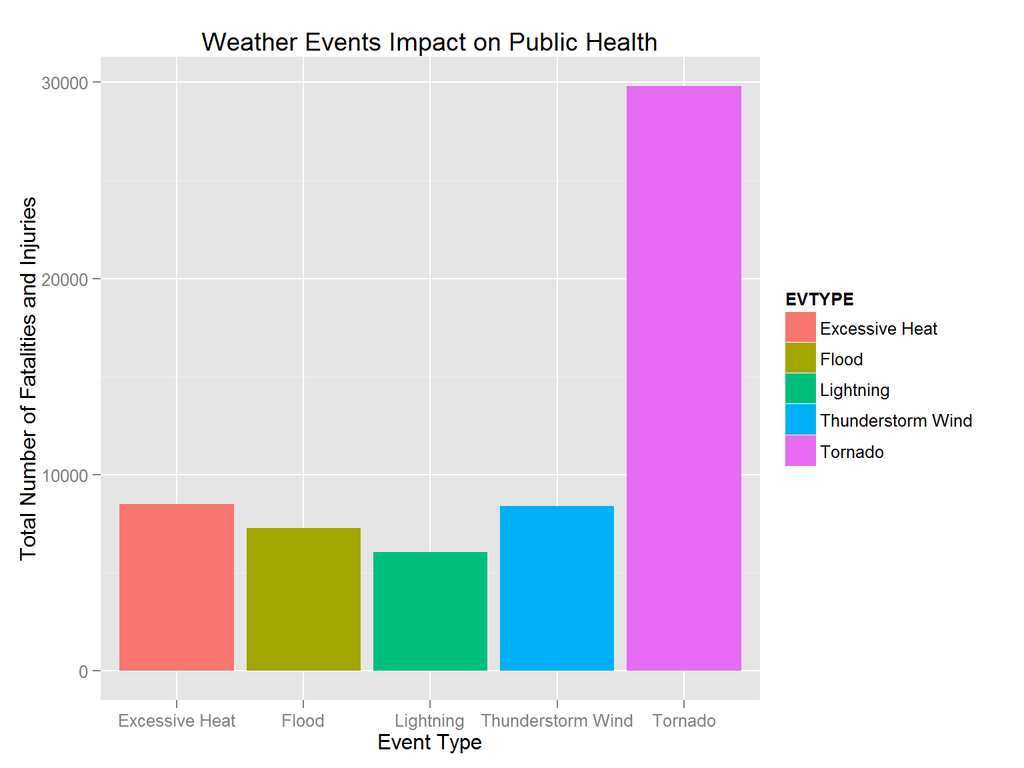

```r
g <- ggplot(data = stormHealthSum5, aes(x=EVTYPE,y=TotalHealthProblems,fill=EVTYPE)) +
    geom_bar(stat = "identity") +
    xlab("Event Type") +
    ylab("Total Number of Fatalities and Injuries") +
    ggtitle("Weather Events Impact on Public Health")
g
```

We can see that **tornadoes** are causing the most fatalities and bodily injuries to people across the United States, based on data from 1989-2011. Flooding, winds and excessive heat are also among the top 5 weather events.

### Impact on Economy in United States

The result we are trying to get at is which types of events have the greatest economic consequences across the United States. For this purpose, we have processed our data in a way to show the total property and crop damage value caused by different events.

Let’s only look at the top 5 event types:

```r
#subset the top 5 events
stormEconSum5 <- stormEconSum[1:5,]
stormEconSum5
```

```
## Source: local data frame [5 x 2]
##
##                EVTYPE TotalEconDamage
## 1               Flood    160903277607
## 2 Hurricane (Typhoon)     90762527810
## 3    Storm Surge/Tide     47965579000
## 4             Tornado     32699685167
## 5                Hail     20737204410
```

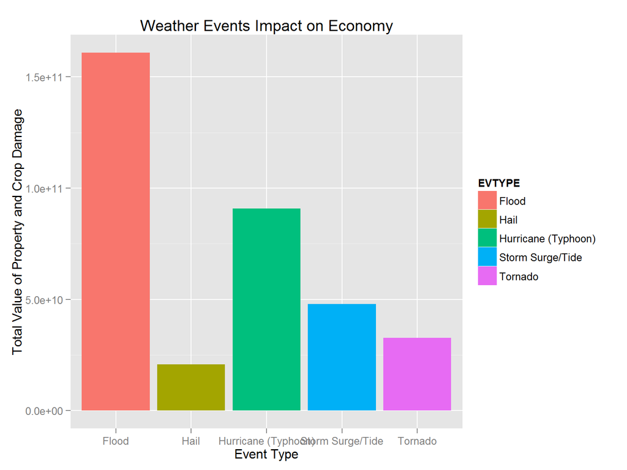

```r
h <- ggplot(data = stormEconSum5, aes(x=EVTYPE,y=TotalEconDamage,fill=EVTYPE)) +
    geom_bar(stat = "identity") +
    xlab("Event Type") +
    ylab("Total Value of Property and Crop Damage") +
    ggtitle("Weather Events Impact on Economy")
h
```

We can see that **floods** are causing the most economic impact across the United States, based on data from 1989-2011. Hurricanes, storms and tornadoes are also among the top 5 weather events.